# Ford-GoBike-System-Data Exploration

## Table of Contents¶

- Introduction
- Dataset Investigation and preliminary wrangling
- Research Questions
- Conclusions and answers

### Introduction

- Dataset: Ford GoBike System Data : https://www.fordgobike.com/system-data
- This dataset represents different bike sharing rides, for example ride duration, start station - end station etc.
- Data is stored on monthly basis. Different files are read to store the data into a data frame

```python
# import libraries
import numpy as np
import pandas as pd
import matplotlib.pyplot as plt
import seaborn as sb
import os
import zipfile
%matplotlib inline
```

```python
# create the path and get the name list under the path
curDir = os.getcwd()
path = curDir+'/Data/'
zip_files = os.listdir(path)

# build the frame df by appending each file
file_list = []
for file in zip_files:
    filename = path+file
    zf = zipfile.ZipFile(filename)
    csvfile=file[:-4]
    df = pd.read_csv(zf.open(csvfile))
    file_list.append(df)
df_bike = pd.concat(file_list)
```

```python
df_bike.head()
```

|  | duration_sec | start_time | end_time | start_station_id | start_station_name | start_station_latitude | start_station_longitude | end_station_id | end_station_name | end_station_latitude | ... | ride_id | rideable_type | started_at | ended_at | start_lat | start_lng | end_lat | end_lng | member_casual | is_equity |
| --- | --- | --- | --- | --- | --- | --- | --- | --- | --- | --- | --- | --- | --- | --- | --- | --- | --- | --- | --- | --- | --- |
| 0 | 80825.0 | 2019-01-31 17:57:44.6130 | 2019-02-01 16:24:49.8640 | 229.0 | Foothill Blvd at 42nd Ave | 37.775745 | -122.213037 | 196.0 | Grand Ave at Perkins St | 37.808894 | ... | NaN | NaN | NaN | NaN | NaN | NaN | NaN | NaN | NaN | NaN |
| 1 | 65900.0 | 2019-01-31 20:58:33.8860 | 2019-02-01 15:16:54.1730 | 4.0 | Cyril Magnin St at Ellis St | 37.785881 | -122.408915 | 134.0 | Valencia St at 24th St | 37.752428 | ... | NaN | NaN | NaN | NaN | NaN | NaN | NaN | NaN | NaN | NaN |
| 2 | 62633.0 | 2019-01-31 18:06:52.9240 | 2019-02-01 11:30:46.5300 | 245.0 | Downtown Berkeley BART | 37.870139 | -122.268422 | 157.0 | 65th St at Hollis St | 37.846784 | ... | NaN | NaN | NaN | NaN | NaN | NaN | NaN | NaN | NaN | NaN |
| 3 | 44680.0 | 2019-01-31 19:46:09.7190 | 2019-02-01 08:10:50.3180 | 85.0 | Church St at Duboce Ave | 37.770083 | -122.429156 | 53.0 | Grove St at Divisadero | 37.775946 | ... | NaN | NaN | NaN | NaN | NaN | NaN | NaN | NaN | NaN | NaN |
| 4 | 60709.0 | 2019-01-31 14:19:01.5410 | 2019-02-01 07:10:51.0650 | 16.0 | Steuart St at Market St | 37.794130 | -122.394430 | 28.0 | The Embarcadero at Bryant St | 37.787168 | ... | NaN | NaN | NaN | NaN | NaN | NaN | NaN | NaN | NaN | NaN |

5 rows × 25 columns

```python
df_bike.info()
```

```
<class 'pandas.core.frame.DataFrame'>
Int64Index: 3792668 entries, 0 to 158167
Data columns (total 25 columns):
 #   Column                   Dtype
---  ------                   -----
 0   duration_sec             float64
 1   start_time               object
 2   end_time                 object
 3   start_station_id         float64
 4   start_station_name       object
 5   start_station_latitude   float64
 6   start_station_longitude  float64
 7   end_station_id           float64
 8   end_station_name         object
 9   end_station_latitude     float64
```

[output cut: 17 more lines]

```python
# data cleaning : drop na rows, not relevant columns etc
df_bike_copy =  df_bike[['duration_sec','start_time','end_time','start_station_name','end_station_name','user_type']]
df_bike_copy.head()
```

|  | duration_sec | start_time | end_time | start_station_name | end_station_name | user_type |
| --- | --- | --- | --- | --- | --- | --- |
| 0 | 80825.0 | 2019-01-31 17:57:44.6130 | 2019-02-01 16:24:49.8640 | Foothill Blvd at 42nd Ave | Grand Ave at Perkins St | Subscriber |
| 1 | 65900.0 | 2019-01-31 20:58:33.8860 | 2019-02-01 15:16:54.1730 | Cyril Magnin St at Ellis St | Valencia St at 24th St | Subscriber |
| 2 | 62633.0 | 2019-01-31 18:06:52.9240 | 2019-02-01 11:30:46.5300 | Downtown Berkeley BART | 65th St at Hollis St | Customer |
| 3 | 44680.0 | 2019-01-31 19:46:09.7190 | 2019-02-01 08:10:50.3180 | Church St at Duboce Ave | Grove St at Divisadero | Customer |
| 4 | 60709.0 | 2019-01-31 14:19:01.5410 | 2019-02-01 07:10:51.0650 | Steuart St at Market St | The Embarcadero at Bryant St | Customer |

```python
df_bike_copy.isnull().sum()
```

```
duration_sec          380678
start_time            380678
end_time              380678
start_station_name    705911
end_station_name      713748
user_type             380678
dtype: int64
```

```python
df_bike_copy.dropna(inplace=True)
```

```python
df_bike_copy.isnull().sum()
```

```
duration_sec          0
start_time            0
end_time              0
start_station_name    0
end_station_name      0
user_type             0
dtype: int64
```

```python
df_bike_copy.shape
```

```
(2754680, 6)
```

## Research questions

1. Which are the top 10 busy stations (start and end)
2. How long does the average trip take?
3. Does the trip durations vary with months or seasons?
4. Does the above depend on if a user is a subscriber or customer?

# Univariate Exploration

> In this section, investigate distributions of individual variables.

**Q1. Which are the top 10 busy stations (start and end)**

```python
# Start station

top_ten_start=df_bike_copy.start_station_name.value_counts()[:10].index
df_bike_copy_sub=df_bike_copy.loc[df_bike_copy['start_station_name'].isin(top_ten_start)]
df_bike_copy_sub.start_station_name=df_bike_copy_sub.start_station_name.str[:40]
```

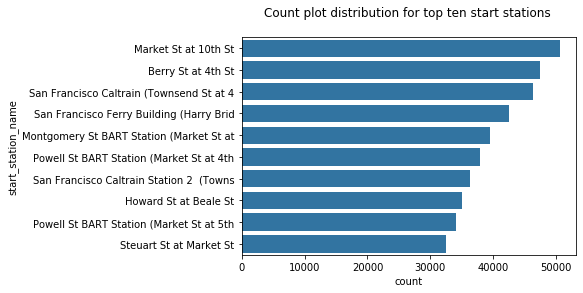

```python
sb.countplot(data = df_bike_copy_sub , y = 'start_station_name',color=sb.color_palette()[0],order=df_bike_copy_sub['start_station_name'].value_counts().index);
plt.title('Count plot distribution for top ten start stations \n');
```

```python
# End station

top_ten_end=df_bike_copy.end_station_name.value_counts()[:10].index
df_bike_copy_sub=df_bike_copy.loc[df_bike_copy['end_station_name'].isin(top_ten_end)]
df_bike_copy_sub.end_station_name=df_bike_copy_sub.end_station_name.str[:40]
```

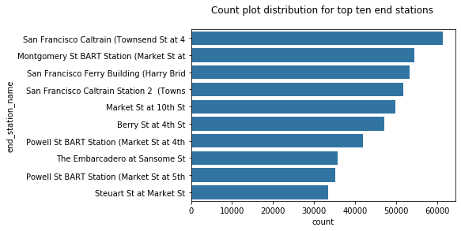

```python
sb.countplot(data = df_bike_copy_sub , y = 'end_station_name',color=sb.color_palette()[0],order=df_bike_copy_sub['end_station_name'].value_counts().index);
plt.title('Count plot distribution for top ten end stations \n')
```

> Most recorded start station - Markt St at 10th St  
> Most recorded end station - Caltrain (Townsend) St

```python
top_ten_end&top_ten_start
```

```
Index(['San Francisco Caltrain (Townsend St at 4th St)',
       'Montgomery St BART Station (Market St at 2nd St)',
       'San Francisco Ferry Building (Harry Bridges Plaza)',
       'San Francisco Caltrain Station 2  (Townsend St at 4th St)',
       'Market St at 10th St', 'Berry St at 4th St',
       'Powell St BART Station (Market St at 4th St)',
       'Powell St BART Station (Market St at 5th St)',
       'Steuart St at Market St'],
      dtype='object')
```

'San Francisco Caltrain (Townsend St at 4th St)','Montgomery St BART Station (Market St at 2nd St)','San Francisco Ferry Building (Harry Bridges Plaza)','San Francisco Caltrain Station 2 (Townsend St at 4th St)','Market St at 10th St', 'Berry St at 4th St','Powell St BART Station (Market St at 4th St)','Powell St BART Station (Market St at 5th St)','Steuart St at Market St' are the busiest stations which are there is top ten start and end stations

**Q2 : How long does the average trip take?**

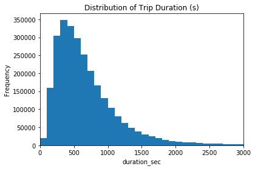

```python
# Histogram plot of the average trip duration
bin_edges = np.arange(0, df_bike_copy['duration_sec'].max() + 100 , 100)
plt.hist(data = df_bike_copy , x = 'duration_sec', bins = bin_edges);
plt.xlim(0,3000);
plt.title('Distribution of Trip Duration (s)');
plt.xlabel('duration_sec');
plt.ylabel('Frequency');
```

> The plot is scewed to the right with a long tail on the right. The bins are 100 seconds, it make better sense to change the unit to minutes and with log transformation of the x axis

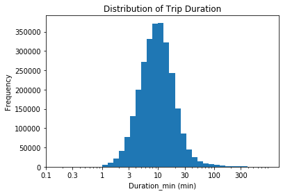

```python
# change the trip duration unit from second to min
df_bike_copy['duration_min'] = df_bike_copy['duration_sec'] / 60
df_bike_copy.drop('duration_sec' , axis = 1 , inplace = True)

bin_edges = 10**np.arange(0 , 3+0.1 , 0.1)
ticks =  [ 0.1 , 0.3 , 1 , 3, 10, 30, 100, 300]
labels = ['{}'.format(v) for v in ticks]
plt.hist(data = df_bike_copy , x = 'duration_min' , bins = bin_edges);
plt.xlabel('Duration_min (min)');
plt.xscale('log');
plt.xticks(ticks,labels);
plt.title('Distribution of Trip Duration');
plt.ylabel('Frequency');
```

> The plot shows that the most of the trips were short trips of around 10 min).

**Q3. Does the trip durations vary with months or seasons? ?**

```python
# create month_start column by extracting months from column start_time

df_bike_copy['month_start'] = pd.DatetimeIndex(df_bike_copy['start_time']).month
df_bike_copy['month_start'].value_counts()
```

```
3     348879
1     316688
2     311857
10    239895
4     239523
9     217986
8     210563
6     189069
7     188010
11    184424
5     182148
12    125638
Name: month_start, dtype: int64
```

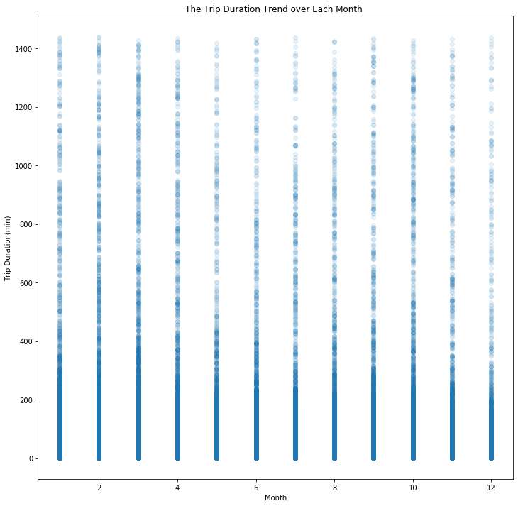

```python
# We can check the trip duration over changes over each month.
plt.figure(figsize = [12,12])
plt.scatter(data = df_bike_copy , x = 'month_start' , y = 'duration_min' , alpha = 0.1 )
plt.title('The Trip Duration Trend over Each Month ')
plt.xlabel('Month')
plt.ylabel('Trip Duration(min)')
```

> March shows some high trip durations. In general all months have similar plots. Need for a deeper analysis.

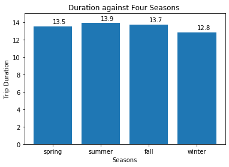

```python
# Create 4 season categories
spring_dur = df_bike_copy.query('month_start in ["3" , "4" , "5"]' ).duration_min.mean ()
summer_dur = df_bike_copy.query('month_start in ["6" , "7" , "8"] ').duration_min.mean()
fall_dur = df_bike_copy.query('month_start in ["9" , "10" , "11"] ').duration_min.mean()
winter_dur = df_bike_copy.query('month_start in ["12" , "1" , "2"]' ).duration_min.mean()
# here the month must be double quote characters, otherwise, give me systax errors
means=[spring_dur , summer_dur , fall_dur , winter_dur]

plt.bar(['spring','summer','fall','winter'],[spring_dur , summer_dur , fall_dur , winter_dur] )
plt.title('Duration against Four Seasons ')
plt.xlabel('Seasons')
plt.ylabel('Trip Duration');
plt.ylim(0,15)
for i,j in enumerate(means):
    pct_string='{:0.1f}'.format(j)
    plt.text(i,j+0.5,pct_string,va='center')
```

- Summer has the longest trip duration , with average above 13.9 mins and winter has the least average trip duration with 12.8 min.
- To sum up, there is no significant difference of average trip duration in terms of four seasons. It is probably because the weather in San Francisco bay area does not change that much.

**Q4 : Does user type lead to the lower trip duration ?**

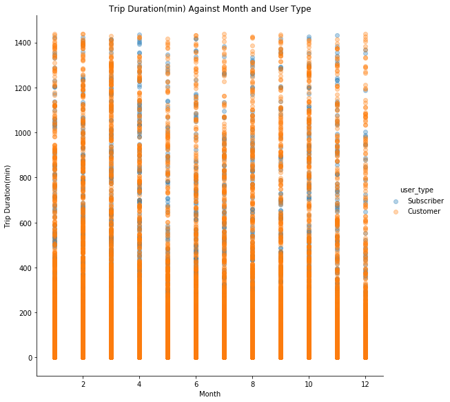

```python
g = sb.FacetGrid(data =  df_bike_copy, hue = 'user_type', size = 8)
g.map(plt.scatter, 'month_start','duration_min', alpha = 1/3)
g.add_legend()
plt.title('Trip Duration(min) Against Month and User Type')
plt.xlabel('Month')
plt.ylabel('Trip Duration(min)');
```